# SE3. Simulation in R #1. Suggested Solution

Author

Mykyta Horovoi

Consider the second-order autoregressive process of a general form from the Exercise #1

$$y_{t} = \delta + \theta_1y_{t-1} + \theta_2y_{t-2} + \varepsilon_{t},\ \varepsilon_{t} \sim iddN(0, \sigma^2)\tag{1}$$

#### 1. Generate a sample of 1000 obs (N = 1000) using the AR(2) process above, assuming $\varepsilon_{t} \sim iddN(0, \sigma^2)$

Substitute suggested parameters from the Exercise #1

$$y_{t} = 2 + 0.3y_{t-1} - 0.6y_{t-2} + \varepsilon_{t}\tag{2}$$

You can simulate $y_{t}$ using the code below:

```r
# set parameters
delta <- 2 # the constant
theta_1 <- 0.3 # the first coefficient
theta_2 <- -0.6 # the second coefficient
n <- 1002 # the number of observations + 2 initial values

# generate an error term
set.seed(23)
epsilon <- rnorm(n = n, mean = 0, sd = 1)
# create an empty vector with n observations
y <- numeric(n)

# create AR(2) process using the for-loop
for (i in (3:n)) {
  y[i] <- delta + theta_1*y[i-1] + theta_2*y[i-2] + epsilon[i]
}
y <- y[3:n] # drop zero values used for initialization
```

You can plot the resulting variable to ensure that the simulation is successful:

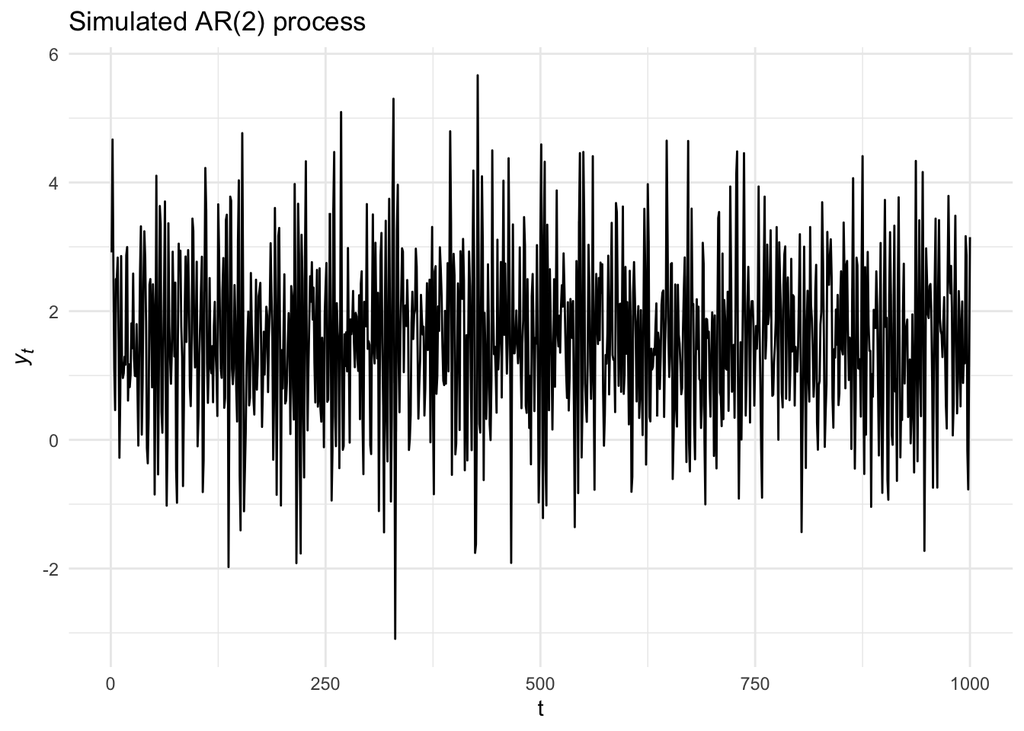

```r
ggplot(mapping = aes(y = y, x = seq(1, n-2))) +
  geom_line() +
  theme_minimal() +
  labs(title = "Simulated AR(2) process",
       x = "t",
       y = "*y<sub>t</sub>*") +
  theme(axis.title.y = element_markdown())
```

#### 2. Get the empirical counterparts of the theoretical ones from the Exercise #1 and compare the results using a table

##### First, get estimated coefficient $\hat{\theta_1}$ and $\hat{\theta_2}$ using the linear regression:

```r
ar2_fit <- lm(y ~ lag(y, 1) + lag(y, 2))
stargazer(ar2_fit, type = "text")
```

```
===============================================
                        Dependent variable:
                    ---------------------------
                                 y
-----------------------------------------------
lag(y, 1)                    0.303***
                              (0.026)

lag(y, 2)                    -0.569***
                              (0.026)

Constant                     1.980***
                              (0.061)

-----------------------------------------------
Observations                    998
R2                             0.350
Adjusted R2                    0.349
Residual Std. Error      1.010 (df = 995)
F Statistic          267.780*** (df = 2; 995)
===============================================
Note:               *p<0.1; **p<0.05; ***p<0.01
```

Write down the estimated equation:

$$\hat{y_{t}} = 1.980 + 0.303\hat{y}_{t-1} - 0.569\hat{y}_{t-2}\tag{3}$$
As you can see, coefficients in $(2)$ and $(3)$ are pretty close.

##### Second, calculate $E(y_t)$, $\gamma_0$, $\gamma_1$, $\rho_0$, $\rho_1$, $\rho_2$, $\rho_3$, $\rho_4$, $\rho_5$.

There are two ways to calculate these values:

1. manual calculation.
2. using estimated coefficients $\hat{\theta_1}$ and $\hat{\theta_2}$.

**1. Manual Calculation**

```r
# sample mean
my_mean_manual <- function(y) {
  sum(y)/length(y)
}
mean_y <- my_mean_manual(y)

# sample variance
my_var_manual <- function(y) {
  temp <- (y - my_mean_manual(y))^2
  sum(temp)/(length(temp)-1)
}
var_y <- my_var_manual(y)

# rho_s
# create the general formula for rho of order s
my_rho_manual <- function(y, order) {
  y_bar <- my_mean_manual(y)
  numerator <- sum((y - y_bar) * (lag(y, order)  - y_bar), na.rm = TRUE)
  denominator <- sum((y - y_bar)^2)
  numerator/denominator
}

# rho_1_5
# calculate autocorrelations up to 5th order
rho_vec_manual <- numeric(5)
for (i in 1:length(rho_vec_manual)) {
  rho_vec_manual[i] <- my_rho_manual(y, i)
}

# calculate gamma_1 from rho_1
gamma_1_manual <- rho_vec_manual[1]*var_y
```

**2. Using Estimated Coefficients** $\hat{\theta_1}$ and $\hat{\theta_2}$

```r
# get estimated coefficients
theta_1_est <- summary(ar2_fit)$coefficients[2,1]
theta_2_est <- summary(ar2_fit)$coefficients[3,1]

# sample mean and variance estimations are the same

# gamma_1
gamma_1 <- (theta_1_est/(1-theta_2_est))*var_y

# rho_s
# create the general formula for rho of order s using recursion
my_rho <- function(order, theta_1, theta_2) {
  if (order == 0) {
    1
  } else if (order == 1) {
    theta_1/(1-theta_2)
  } else {
    theta_1*my_rho(order - 1, theta_1, theta_2) + theta_2*my_rho(order - 2, theta_1, theta_2)
    }
}
# rho_0
rho_0 <- my_rho(0, theta_1_est, theta_2_est)

# rho_1_5
# calculate autocorrelations up to 5th order
rho_vec <- numeric(5)
for (i in 1:length(rho_vec)) {
  rho_vec[i] <- my_rho(i, theta_1_est, theta_2_est)
}
```

Notice that resulting parameter values differ slightly between approaches:

| Parameter | Manual Calculation | Using Estimated Coefficients |
| --- | --- | --- |
| $\gamma_1$ | 0.3057 | 0.3041 |
| $\rho_1$ | 0.1943 | 0.1933 |
| $\rho_2$ | -0.5086 | -0.5101 |
| $\rho_3$ | -0.2796 | -0.2646 |
| $\rho_4$ | 0.1833 | 0.2098 |
| $\rho_5$ | 0.1882 | 0.2141 |

##### Third, calculate theoretical parameters:

```r
# mean
mean_t <- delta/(1 - theta_1 - theta_2)

# rho_1_5
rho_vec_t <- numeric(5)
for (i in 1:length(rho_vec_t)) {
  rho_vec_t[i] <- my_rho(i, theta_1, theta_2)
}

# var
var_y_t <- 1/(1 - theta_1*rho_vec_t[1] - theta_2*rho_vec_t[2])
gamma_1_y_t <- (theta_1/(1 - theta_2))*var_y_t
```

Finally, compare empirical (manual) counterparts with the theoretical ones:

| Parameter | Theoretical Value | Empirical Value |
| --- | --- | --- |
| $E(y_t)$ | 1.5385 | 1.568 |
| $\gamma_0$ | 1.6194 | 1.5733 |
| $\gamma_1$ | 0.3036 | 0.3057 |
| $\rho_0$ | 1 | 1 |
| $\rho_1$ | 0.1875 | 0.1943 |
| $\rho_2$ | -0.5438 | -0.5086 |
| $\rho_3$ | -0.2756 | -0.2796 |
| $\rho_4$ | 0.2436 | 0.1833 |
| $\rho_5$ | 0.2384 | 0.1882 |
| $\phi_{11}$ | 0.1875 | 0.1943 |
| $\phi_{22}$ | -0.6 | -0.5687 |

**End of the suggested solution.**